# Analysis of the 2017-2018 schol year kindergarten lottery

- Introduction
- Data Wrangling
- Questions about the data set

## Introduction

4,611 children entered the 2017-2018 San Francisco Unified School District kindergarten lottery. Parents can select multiple schools, and they made more than 45,000 unique choices. This Jupyter Noteboook reviews data analyzed by KQED for this news article: https://www.kqed.org/news/11641019/s-f-s-kindergarten-lottery-do-parents-tricks-work, using this base workbook: https://github.com/pickoffwhite/San-Francisco-Kindergarten-Lottery

In addition the the baseline review, already set forth by the KQED team, this notebook looks at

- those applications that listed three schools
- the impact of zipcode and CTIP status on choices, assignments, and enrollments

Data limitations: Additional data would help ascertain how selections connect with language requirements for the bilitieracy and immersion programs. And, additional data can help assess how AA and sibling preference impact assignments and enrollment.

```python
# Importing packages and functions
import pandas as pd
import numpy as np
import datetime # operations to parse dates
import time
import csv
from pprint import pprint #for pretty printing dictionaries
#import ggplot as gplot
import matplotlib as mpl # Still required to change the sizes of plots
import matplotlib.pyplot as plt
import matplotlib.gridspec as gridspec
% matplotlib inline
import seaborn as sns
```

## Data Wrangling

### General Properties

```python
lotto = pd.read_csv('./data/kqed_data/20171103_KQED_KinderAssignmentData_201718_k_placement_2017_2018.csv', dtype = object)
df=lotto.copy()
```

```python
lotto.info();
```

```
<class 'pandas.core.frame.DataFrame'>
RangeIndex: 4611 entries, 0 to 4610
Data columns (total 98 columns):
StudentNo                                 4611 non-null object
1                                         4611 non-null object
2                                         3856 non-null object
3                                         3441 non-null object
4                                         3028 non-null object
5                                         2657 non-null object
6                                         2361 non-null object
7                                         2114 non-null object
8                                         1938 non-null object
9                                         1804 non-null object
10                                        1668 non-null object
11                                        1147 non-null object
```

[output cut: 88 more lines]

```python
lotto.duplicated().sum()
```

```
0
```

```python
lotto.nunique().sum()
```

```
8892
```

```python
lotto.head()
```

|  | StudentNo | 1 | 2 | 3 | 4 | 5 | 6 | 7 | 8 | 9 | ... | 88 | 89 | 90 | 91 | 92 | Round 1 Assignment | School Enrolled In As Of 11/03/2017 | Student's Ethnicity | Does Student Live In CTIP1 Zone? (y/n) | Student's Residential Zip Code |
| --- | --- | --- | --- | --- | --- | --- | --- | --- | --- | --- | --- | --- | --- | --- | --- | --- | --- | --- | --- | --- | --- |
| 0 | 1 | 848 | 569 | NaN | NaN | NaN | NaN | NaN | NaN | NaN | ... | NaN | NaN | NaN | NaN | NaN | 848 | 848 | White, Not of Hispanic Origin | N | 94118 |
| 1 | 2 | 420 | 420 | 537 | 729 | NaN | NaN | NaN | NaN | NaN | ... | NaN | NaN | NaN | NaN | NaN | 729 | 729 | Hispanic | N | 94112 |
| 2 | 3 | 478 | 589 | 722 | 664 | 539 | 796 | 420 | 413 | 569 | ... | NaN | NaN | NaN | NaN | NaN | 722 | 722 | White, Not of Hispanic Origin | N | 94131 |
| 3 | 4 | 782 | 676 | 478 | NaN | NaN | NaN | NaN | NaN | NaN | ... | NaN | NaN | NaN | NaN | NaN | 782 | 782 | Asian or Pacific Islander | N | 94127 |
| 4 | 5 | 420 | 618 | NaN | NaN | NaN | NaN | NaN | NaN | NaN | ... | NaN | NaN | NaN | NaN | NaN | 420 | 420 | Hispanic | Y | 94110 |

5 rows × 98 columns

# Data Cleaning

### Manage CTIP column

```python
#seperate out the data columns that I will be working with
zipdata = df.iloc[:, [0,93,94,96,97]]
zipdata.info()
```

```
<class 'pandas.core.frame.DataFrame'>
RangeIndex: 4611 entries, 0 to 4610
Data columns (total 5 columns):
StudentNo                                 4611 non-null object
Round 1 Assignment                        4470 non-null object
School Enrolled In As Of 11/03/2017       4043 non-null object
Does Student Live In CTIP1 Zone? (y/n)    4611 non-null object
Student's Residential Zip Code            4611 non-null object
dtypes: object(5)
memory usage: 180.2+ KB
```

```python
#convert data types
zipdata = zipdata.convert_objects(convert_numeric=True)
zipdata.dtypes
```

```
StudentNo                                   int64
Round 1 Assignment                        float64
School Enrolled In As Of 11/03/2017       float64
Does Student Live In CTIP1 Zone? (y/n)     object
Student's Residential Zip Code              int64
dtype: object
```

```python
#Replace 'Y' and 'N' with 1 and 0 for 'Not CTIP'
  #1 = yes CTIP #0 = is not a CTIP applicant
zipdata['Does Student Live In CTIP1 Zone? (y/n)'].replace({'N':0, 'Y': 1}, inplace=True)
```

```python
zipdata.dtypes
```

```
StudentNo                                   int64
Round 1 Assignment                        float64
School Enrolled In As Of 11/03/2017       float64
Does Student Live In CTIP1 Zone? (y/n)      int64
Student's Residential Zip Code              int64
dtype: object
```

```python
pd.options.display.float_format = '{:,.0f}'.format
```

```python
zipdata.head()
```

|  | StudentNo | Round 1 Assignment | School Enrolled In As Of 11/03/2017 | Does Student Live In CTIP1 Zone? (y/n) | Student's Residential Zip Code |
| --- | --- | --- | --- | --- | --- |
| 0 | 1 | 848 | 848 | 0 | 94118 |
| 1 | 2 | 729 | 729 | 0 | 94112 |
| 2 | 3 | 722 | 722 | 0 | 94131 |
| 3 | 4 | 782 | 782 | 0 | 94127 |
| 4 | 5 | 420 | 420 | 1 | 94110 |

# Questions about the data

## How many students enrolled in their Round 1 top choice school?

> **2810 students... 60.94% of students**

There are students that entered the lottery late. The school that those students enroll in becomes their first choice in the data. We are going to exclude them from the dataset. We can tell who they are because they did not received a round one assignment, so their data is null, according to the San Francisco School District. This year there were 141 students that entered the lotter late.

```python
late = lotto['Round 1 Assignment']
late.isna().sum()
```

```
141
```

```python
lotto.dropna(subset=['Round 1 Assignment'])
```

|  | StudentNo | 1 | 2 | 3 | 4 | 5 | 6 | 7 | 8 | 9 | ... | 88 | 89 | 90 | 91 | 92 | Round 1 Assignment | School Enrolled In As Of 11/03/2017 | Student's Ethnicity | Does Student Live In CTIP1 Zone? (y/n) | Student's Residential Zip Code |
| --- | --- | --- | --- | --- | --- | --- | --- | --- | --- | --- | --- | --- | --- | --- | --- | --- | --- | --- | --- | --- | --- |
| 0 | 1 | 848 | 569 | NaN | NaN | NaN | NaN | NaN | NaN | NaN | ... | NaN | NaN | NaN | NaN | NaN | 848 | 848 | White, Not of Hispanic Origin | N | 94118 |
| 1 | 2 | 420 | 420 | 537 | 729 | NaN | NaN | NaN | NaN | NaN | ... | NaN | NaN | NaN | NaN | NaN | 729 | 729 | Hispanic | N | 94112 |
| 2 | 3 | 478 | 589 | 722 | 664 | 539 | 796 | 420 | 413 | 569 | ... | NaN | NaN | NaN | NaN | NaN | 722 | 722 | White, Not of Hispanic Origin | N | 94131 |
| 3 | 4 | 782 | 676 | 478 | NaN | NaN | NaN | NaN | NaN | NaN | ... | NaN | NaN | NaN | NaN | NaN | 782 | 782 | Asian or Pacific Islander | N | 94127 |
| 4 | 5 | 420 | 618 | NaN | NaN | NaN | NaN | NaN | NaN | NaN | ... | NaN | NaN | NaN | NaN | NaN | 420 | 420 | Hispanic | Y | 94110 |
| 5 | 6 | 838 | 746 | 478 | 876 | 488 | 848 | 729 | 569 | 796 | ... | NaN | NaN | NaN | NaN | NaN | 838 | 838 | Asian or Pacific Islander | N | 94134 |
| 6 | 7 | 485 | 876 | 513 | 513 | 478 | 862 | 862 | 782 | 760 | ... | NaN | NaN | NaN | NaN | NaN | 760 | 614 | Declines To State | N | 94134 |
| 7 | 8 | 859 | 449 | 790 | NaN | NaN | NaN | NaN | NaN | NaN | ... | NaN | NaN | NaN | NaN | NaN | 859 | 859 | Hispanic | N | 94102 |
| 8 | 9 | 420 | NaN | NaN | NaN | NaN | NaN | NaN | NaN | NaN | ... | NaN | NaN | NaN | NaN | NaN | 420 | 420 | Declines To State | Y | 94107 |
| 9 | 10 | 782 | NaN | NaN | NaN | NaN | NaN | NaN | NaN | NaN | ... | NaN | NaN | NaN | NaN | NaN | 782 | 782 | Declines To State | N | 94112 |
| 10 | 11 | 485 | 676 | 862 | 750 | 746 | 539 | 435 | 782 | 644 | ... | NaN | NaN | NaN | NaN | NaN | 862 | 862 | Asian or Pacific Islander | N | 94116 |
| 11 | 12 | 676 | 796 | 485 | 478 | 478 | 420 | 420 | 497 | 589 | ... | NaN | NaN | NaN | NaN | NaN | 676 | 676 | Declines To State | Y | 94107 |
| 12 | 13 | 842 | 722 | 575 | 478 | 488 | 876 | 420 | 796 | 539 | ... | NaN | NaN | NaN | NaN | NaN | 842 | 842 | White, Not of Hispanic Origin | N | 94127 |
| 13 | 14 | 862 | 876 | 509 | 862 | 876 | 488 | 490 | NaN | NaN | ... | NaN | NaN | NaN | NaN | NaN | 490 | 490 | Asian or Pacific Islander | N | 94112 |
| 15 | 16 | 746 | NaN | NaN | NaN | NaN | NaN | NaN | NaN | NaN | ... | NaN | NaN | NaN | NaN | NaN | 746 | 746 | Declines To State | N | 94112 |
| 16 | 17 | 676 | 782 | 750 | 485 | 644 | 876 | 862 | 876 | 544 | ... | NaN | NaN | NaN | NaN | NaN | 782 | 782 | Asian or Pacific Islander | N | 94132 |
| 17 | 18 | 435 | NaN | NaN | NaN | NaN | NaN | NaN | NaN | NaN | ... | NaN | NaN | NaN | NaN | NaN | 435 | 435 | Declines To State | N | 94121 |
| 18 | 19 | 796 | 420 | 478 | 722 | 876 | 718 | 589 | 479 | 413 | ... | NaN | NaN | NaN | NaN | NaN | 420 | NaN | Declines To State | N | 94114 |
| 19 | 20 | 676 | 782 | 644 | 750 | 862 | 876 | 539 | NaN | NaN | ... | NaN | NaN | NaN | NaN | NaN | 676 | 676 | Asian or Pacific Islander | N | 94112 |
| 20 | 21 | 478 | 735 | 420 | 435 | 485 | 676 | 750 | 544 | 876 | ... | NaN | NaN | NaN | NaN | NaN | 478 | 478 | White, Not of Hispanic Origin | N | 94122 |
| 21 | 22 | 867 | NaN | NaN | NaN | NaN | NaN | NaN | NaN | NaN | ... | NaN | NaN | NaN | NaN | NaN | 867 | 867 | Asian or Pacific Islander | N | 94134 |
| 22 | 23 | 488 | NaN | NaN | NaN | NaN | NaN | NaN | NaN | NaN | ... | NaN | NaN | NaN | NaN | NaN | 488 | 488 | Declines To State | N | 94112 |
| 23 | 24 | 569 | 479 | 782 | 750 | 644 | 413 | 876 | 435 | 485 | ... | NaN | NaN | NaN | NaN | NaN | 656 | 860 | Declines To State | N | 94131 |
| 24 | 25 | 862 | 867 | NaN | NaN | NaN | NaN | NaN | NaN | NaN | ... | NaN | NaN | NaN | NaN | NaN | 867 | 525 | Declines To State | N | 94116 |
| 25 | 26 | 562 | NaN | NaN | NaN | NaN | NaN | NaN | NaN | NaN | ... | NaN | NaN | NaN | NaN | NaN | 562 | 562 | Hispanic | N | 94117 |
| 26 | 27 | 782 | 676 | 485 | 509 | 544 | 750 | 644 | 569 | 549 | ... | NaN | NaN | NaN | NaN | NaN | 782 | 782 | Asian or Pacific Islander | N | 94103 |
| 27 | 28 | 664 | 796 | 479 | 625 | NaN | NaN | NaN | NaN | NaN | ... | NaN | NaN | NaN | NaN | NaN | 625 | 875 | Hispanic | N | 94129 |
| 28 | 29 | 562 | NaN | NaN | NaN | NaN | NaN | NaN | NaN | NaN | ... | NaN | NaN | NaN | NaN | NaN | 562 | 562 | Hispanic | N | 94107 |
| 29 | 30 | 718 | 589 | 796 | 735 | 786 | 420 | 505 | 478 | 569 | ... | NaN | NaN | NaN | NaN | NaN | 718 | 718 | White, Not of Hispanic Origin | N | 94114 |
| 30 | 31 | 509 | 485 | NaN | NaN | NaN | NaN | NaN | NaN | NaN | ... | NaN | NaN | NaN | NaN | NaN | 509 | 509 | Declines To State | N | 94132 |
| ... | ... | ... | ... | ... | ... | ... | ... | ... | ... | ... | ... | ... | ... | ... | ... | ... | ... | ... | ... | ... | ... |
| 4581 | 4582 | 420 | 420 | 876 | 722 | 796 | 862 | 488 | 478 | 842 | ... | NaN | NaN | NaN | NaN | NaN | 656 | 656 | White, Not of Hispanic Origin | N | 94112 |
| 4582 | 4583 | 485 | NaN | NaN | NaN | NaN | NaN | NaN | NaN | NaN | ... | NaN | NaN | NaN | NaN | NaN | 485 | 485 | Asian or Pacific Islander | N | 94112 |
| 4583 | 4584 | 449 | NaN | NaN | NaN | NaN | NaN | NaN | NaN | NaN | ... | NaN | NaN | NaN | NaN | NaN | 449 | 859 | NaN | Y | 94115 |
| 4584 | 4585 | 814 | NaN | NaN | NaN | NaN | NaN | NaN | NaN | NaN | ... | NaN | NaN | NaN | NaN | NaN | 814 | 814 | Hispanic | N | 94124 |
| 4585 | 4586 | 589 | 718 | 478 | 796 | 722 | 814 | 735 | 569 | 420 | ... | NaN | NaN | NaN | NaN | NaN | 589 | 938 | White, Not of Hispanic Origin | N | 94117 |
| 4586 | 4587 | 507 | NaN | NaN | NaN | NaN | NaN | NaN | NaN | NaN | ... | NaN | NaN | NaN | NaN | NaN | 507 | 507 | NaN | Y | 94124 |
| 4587 | 4588 | 644 | 676 | 782 | 750 | 589 | 664 | 862 | 569 | 544 | ... | NaN | NaN | NaN | NaN | NaN | 644 | 644 | Asian or Pacific Islander | N | 94122 |
| 4588 | 4589 | 537 | 420 | 456 | 680 | 618 | 760 | 723 | NaN | NaN | ... | NaN | NaN | NaN | NaN | NaN | 456 | 456 | Hispanic | N | 94124 |
| 4589 | 4590 | 796 | NaN | NaN | NaN | NaN | NaN | NaN | NaN | NaN | ... | NaN | NaN | NaN | NaN | NaN | 796 | 796 | Hispanic | N | 94134 |
| 4590 | 4591 | 603 | 656 | 722 | 575 | NaN | NaN | NaN | NaN | NaN | ... | NaN | NaN | NaN | NaN | NaN | 603 | 614 | Hispanic | N | 94112 |
| 4591 | 4592 | 435 | 413 | 664 | 569 | 676 | 848 | 485 | 750 | 544 | ... | NaN | NaN | NaN | NaN | NaN | 859 | 544 | Asian or Pacific Islander | N | 94121 |
| 4592 | 4593 | 823 | 525 | 801 | 790 | 718 | 638 | NaN | NaN | NaN | ... | NaN | NaN | NaN | NaN | NaN | 525 | 525 | Black, Not of Hispanic Origin | N | 94115 |
| 4593 | 4594 | 796 | 478 | 589 | 722 | 876 | 842 | 718 | 513 | NaN | ... | NaN | NaN | NaN | NaN | NaN | 796 | 796 | Asian or Pacific Islander | N | 94134 |
| 4594 | 4595 | 521 | NaN | NaN | NaN | NaN | NaN | NaN | NaN | NaN | ... | NaN | NaN | NaN | NaN | NaN | 521 | 521 | Hispanic | N | 94134 |
| 4595 | 4596 | 760 | 449 | 796 | 420 | 435 | 488 | 478 | 722 | 479 | ... | NaN | NaN | NaN | NaN | NaN | 760 | 760 | Asian or Pacific Islander | N | 94124 |
| 4596 | 4597 | 750 | 876 | 876 | 478 | 478 | 485 | 676 | 644 | NaN | ... | NaN | NaN | NaN | NaN | NaN | 750 | 750 | Asian or Pacific Islander | N | 94122 |
| 4597 | 4598 | 796 | 420 | 420 | 876 | 478 | 589 | 718 | 485 | 722 | ... | NaN | NaN | NaN | NaN | NaN | 420 | 420 | NaN | N | 94114 |
| 4598 | 4599 | 816 | NaN | NaN | NaN | NaN | NaN | NaN | NaN | NaN | ... | NaN | NaN | NaN | NaN | NaN | 816 | 816 | Hispanic | Y | 94110 |
| 4599 | 4600 | 670 | 750 | 644 | 876 | 796 | NaN | NaN | NaN | NaN | ... | NaN | NaN | NaN | NaN | NaN | 670 | 670 | White, Not of Hispanic Origin | N | 94127 |
| 4600 | 4601 | 872 | 490 | 638 | 834 | 801 | 562 | 562 | 823 | 790 | ... | NaN | NaN | NaN | NaN | NaN | 490 | 490 | Asian or Pacific Islander | N | 94108 |
| 4601 | 4602 | 449 | 796 | 537 | 814 | 735 | 723 | 478 | 664 | 676 | ... | NaN | NaN | NaN | NaN | NaN | 449 | 449 | NaN | Y | 94124 |
| 4602 | 4603 | 478 | 478 | 420 | 796 | 644 | 842 | 722 | 676 | 479 | ... | NaN | NaN | NaN | NaN | NaN | 478 | 478 | White, Not of Hispanic Origin | Y | 94109 |
| 4603 | 4604 | 618 | 714 | 537 | 729 | 723 | NaN | NaN | NaN | NaN | ... | NaN | NaN | NaN | NaN | NaN | 618 | 618 | Hispanic | Y | 94110 |
| 4604 | 4605 | 478 | 478 | 876 | 876 | 796 | 589 | 420 | 420 | 575 | ... | NaN | NaN | NaN | NaN | NaN | 816 | 201 | NaN | N | 94131 |
| 4605 | 4606 | 644 | 413 | 664 | 435 | 670 | 497 | 569 | 848 | 750 | ... | NaN | NaN | NaN | NaN | NaN | 670 | 670 | White, Not of Hispanic Origin | N | 94118 |
| 4606 | 4607 | 867 | NaN | NaN | NaN | NaN | NaN | NaN | NaN | NaN | ... | NaN | NaN | NaN | NaN | NaN | 867 | 867 | Asian or Pacific Islander | N | 94134 |
| 4607 | 4608 | 618 | 796 | 760 | NaN | NaN | NaN | NaN | NaN | NaN | ... | NaN | NaN | NaN | NaN | NaN | 618 | 618 | NaN | N | 94110 |
| 4608 | 4609 | 820 | 488 | 691 | 691 | NaN | NaN | NaN | NaN | NaN | ... | NaN | NaN | NaN | NaN | NaN | 820 | 820 | Hispanic | N | 94112 |
| 4609 | 4610 | 834 | 490 | 638 | 562 | 525 | 650 | NaN | NaN | NaN | ... | NaN | NaN | NaN | NaN | NaN | 834 | 834 | NaN | Y | 94109 |
| 4610 | 4611 | 718 | 722 | 814 | 823 | 413 | 420 | NaN | NaN | NaN | ... | NaN | NaN | NaN | NaN | NaN | 718 | 718 | White, Not of Hispanic Origin | Y | 94115 |

4470 rows × 98 columns

```python
lotto['got1stchoice'] = np.where(lotto['1'] == lotto['School Enrolled In As Of 11/03/2017'], 'yes', 'no')
```

```python
lotto.got1stchoice.value_counts()
```

```
yes    2810
no     1801
Name: got1stchoice, dtype: int64
```

```python
lotto.got1stchoice.value_counts('yes')
```

```
yes   1
no    0
Name: got1stchoice, dtype: float64
```

## How many students enrolled in one of the schools in their first three, five, and ten choices.

We're filtering down the dataframe to the first five schools, and then seeing how many match.

> **Top 3: 73%**

> **Top 5: 76%**

> **Top 10: 79%**

```python
lotto2 = lotto[['School Enrolled In As Of 11/03/2017','1','2']]
```

```python
lotto['gottop2'] = lotto2.drop("School Enrolled In As Of 11/03/2017", 1).isin(lotto2["School Enrolled In As Of 11/03/2017"]).any(1)
```

```python
lotto.gottop2.value_counts(True)
```

```
True    1
False   0
Name: gottop2, dtype: float64
```

```python
lotto3 = lotto[['School Enrolled In As Of 11/03/2017','1','2','3']]
```

```python
lotto['gottop3'] = lotto3.drop("School Enrolled In As Of 11/03/2017", 1).isin(lotto3["School Enrolled In As Of 11/03/2017"]).any(1)
```

```python
lotto.gottop3.value_counts(True)
```

```
True    1
False   0
Name: gottop3, dtype: float64
```

How many students enrolled in one of the schools in their top 5 schools. We're filtering down the dataframe to the first ten schools, and then seeing how many match.

```python
lotto5 = lotto[['School Enrolled In As Of 11/03/2017','1','2','3','4','5']]
```

```python
lotto['gottop5'] = lotto5.drop("School Enrolled In As Of 11/03/2017", 1).isin(lotto5["School Enrolled In As Of 11/03/2017"]).any(1)
```

```python
lotto.gottop5.value_counts(True)
```

```
True    1
False   0
Name: gottop5, dtype: float64
```

How many students enrolled in one of the schools in their top 10 choices. We're filtering down the dataframe to the first ten schools, and then seeing how many match.

```python
lotto10 = lotto[['School Enrolled In As Of 11/03/2017','1','2','3','4','5', '6', '7', '8', '9', '10']]
```

```python
lotto['gottop10'] = lotto10.drop("School Enrolled In As Of 11/03/2017", 1).isin(lotto10["School Enrolled In As Of 11/03/2017"]).any(1)
```

```python
lotto.gottop10.value_counts(True)
```

```
True    1
False   0
Name: gottop10, dtype: float64
```

```python
lotto.reset_index()
```

|  | index | StudentNo | 1 | 2 | 3 | 4 | 5 | 6 | 7 | 8 | ... | Round 1 Assignment | School Enrolled In As Of 11/03/2017 | Student's Ethnicity | Does Student Live In CTIP1 Zone? (y/n) | Student's Residential Zip Code | got1stchoice | gottop2 | gottop3 | gottop5 | gottop10 |
| --- | --- | --- | --- | --- | --- | --- | --- | --- | --- | --- | --- | --- | --- | --- | --- | --- | --- | --- | --- | --- | --- |
| 0 | 0 | 1 | 848 | 569 | NaN | NaN | NaN | NaN | NaN | NaN | ... | 848 | 848 | White, Not of Hispanic Origin | N | 94118 | yes | True | True | True | True |
| 1 | 1 | 2 | 420 | 420 | 537 | 729 | NaN | NaN | NaN | NaN | ... | 729 | 729 | Hispanic | N | 94112 | no | False | False | True | True |
| 2 | 2 | 3 | 478 | 589 | 722 | 664 | 539 | 796 | 420 | 413 | ... | 722 | 722 | White, Not of Hispanic Origin | N | 94131 | no | False | True | True | True |
| 3 | 3 | 4 | 782 | 676 | 478 | NaN | NaN | NaN | NaN | NaN | ... | 782 | 782 | Asian or Pacific Islander | N | 94127 | yes | True | True | True | True |
| 4 | 4 | 5 | 420 | 618 | NaN | NaN | NaN | NaN | NaN | NaN | ... | 420 | 420 | Hispanic | Y | 94110 | yes | True | True | True | True |
| 5 | 5 | 6 | 838 | 746 | 478 | 876 | 488 | 848 | 729 | 569 | ... | 838 | 838 | Asian or Pacific Islander | N | 94134 | yes | True | True | True | True |
| 6 | 6 | 7 | 485 | 876 | 513 | 513 | 478 | 862 | 862 | 782 | ... | 760 | 614 | Declines To State | N | 94134 | no | False | False | False | False |
| 7 | 7 | 8 | 859 | 449 | 790 | NaN | NaN | NaN | NaN | NaN | ... | 859 | 859 | Hispanic | N | 94102 | yes | True | True | True | True |
| 8 | 8 | 9 | 420 | NaN | NaN | NaN | NaN | NaN | NaN | NaN | ... | 420 | 420 | Declines To State | Y | 94107 | yes | True | True | True | True |
| 9 | 9 | 10 | 782 | NaN | NaN | NaN | NaN | NaN | NaN | NaN | ... | 782 | 782 | Declines To State | N | 94112 | yes | True | True | True | True |
| 10 | 10 | 11 | 485 | 676 | 862 | 750 | 746 | 539 | 435 | 782 | ... | 862 | 862 | Asian or Pacific Islander | N | 94116 | no | False | True | True | True |
| 11 | 11 | 12 | 676 | 796 | 485 | 478 | 478 | 420 | 420 | 497 | ... | 676 | 676 | Declines To State | Y | 94107 | yes | True | True | True | True |
| 12 | 12 | 13 | 842 | 722 | 575 | 478 | 488 | 876 | 420 | 796 | ... | 842 | 842 | White, Not of Hispanic Origin | N | 94127 | yes | True | True | True | True |
| 13 | 13 | 14 | 862 | 876 | 509 | 862 | 876 | 488 | 490 | NaN | ... | 490 | 490 | Asian or Pacific Islander | N | 94112 | no | False | False | False | True |
| 14 | 14 | 15 | 676 | 485 | 750 | 644 | 782 | 876 | 746 | 876 | ... | NaN | NaN | Asian or Pacific Islander | N | 94132 | no | False | False | False | False |
| 15 | 15 | 16 | 746 | NaN | NaN | NaN | NaN | NaN | NaN | NaN | ... | 746 | 746 | Declines To State | N | 94112 | yes | True | True | True | True |
| 16 | 16 | 17 | 676 | 782 | 750 | 485 | 644 | 876 | 862 | 876 | ... | 782 | 782 | Asian or Pacific Islander | N | 94132 | no | True | True | True | True |
| 17 | 17 | 18 | 435 | NaN | NaN | NaN | NaN | NaN | NaN | NaN | ... | 435 | 435 | Declines To State | N | 94121 | yes | True | True | True | True |
| 18 | 18 | 19 | 796 | 420 | 478 | 722 | 876 | 718 | 589 | 479 | ... | 420 | NaN | Declines To State | N | 94114 | no | False | False | False | False |
| 19 | 19 | 20 | 676 | 782 | 644 | 750 | 862 | 876 | 539 | NaN | ... | 676 | 676 | Asian or Pacific Islander | N | 94112 | yes | True | True | True | True |
| 20 | 20 | 21 | 478 | 735 | 420 | 435 | 485 | 676 | 750 | 544 | ... | 478 | 478 | White, Not of Hispanic Origin | N | 94122 | yes | True | True | True | True |
| 21 | 21 | 22 | 867 | NaN | NaN | NaN | NaN | NaN | NaN | NaN | ... | 867 | 867 | Asian or Pacific Islander | N | 94134 | yes | True | True | True | True |
| 22 | 22 | 23 | 488 | NaN | NaN | NaN | NaN | NaN | NaN | NaN | ... | 488 | 488 | Declines To State | N | 94112 | yes | True | True | True | True |
| 23 | 23 | 24 | 569 | 479 | 782 | 750 | 644 | 413 | 876 | 435 | ... | 656 | 860 | Declines To State | N | 94131 | no | False | False | False | False |
| 24 | 24 | 25 | 862 | 867 | NaN | NaN | NaN | NaN | NaN | NaN | ... | 867 | 525 | Declines To State | N | 94116 | no | False | False | False | False |
| 25 | 25 | 26 | 562 | NaN | NaN | NaN | NaN | NaN | NaN | NaN | ... | 562 | 562 | Hispanic | N | 94117 | yes | True | True | True | True |
| 26 | 26 | 27 | 782 | 676 | 485 | 509 | 544 | 750 | 644 | 569 | ... | 782 | 782 | Asian or Pacific Islander | N | 94103 | yes | True | True | True | True |
| 27 | 27 | 28 | 664 | 796 | 479 | 625 | NaN | NaN | NaN | NaN | ... | 625 | 875 | Hispanic | N | 94129 | no | False | False | False | False |
| 28 | 28 | 29 | 562 | NaN | NaN | NaN | NaN | NaN | NaN | NaN | ... | 562 | 562 | Hispanic | N | 94107 | yes | True | True | True | True |
| 29 | 29 | 30 | 718 | 589 | 796 | 735 | 786 | 420 | 505 | 478 | ... | 718 | 718 | White, Not of Hispanic Origin | N | 94114 | yes | True | True | True | True |
| ... | ... | ... | ... | ... | ... | ... | ... | ... | ... | ... | ... | ... | ... | ... | ... | ... | ... | ... | ... | ... | ... |
| 4581 | 4581 | 4582 | 420 | 420 | 876 | 722 | 796 | 862 | 488 | 478 | ... | 656 | 656 | White, Not of Hispanic Origin | N | 94112 | no | False | False | False | True |
| 4582 | 4582 | 4583 | 485 | NaN | NaN | NaN | NaN | NaN | NaN | NaN | ... | 485 | 485 | Asian or Pacific Islander | N | 94112 | yes | True | True | True | True |
| 4583 | 4583 | 4584 | 449 | NaN | NaN | NaN | NaN | NaN | NaN | NaN | ... | 449 | 859 | NaN | Y | 94115 | no | False | False | False | False |
| 4584 | 4584 | 4585 | 814 | NaN | NaN | NaN | NaN | NaN | NaN | NaN | ... | 814 | 814 | Hispanic | N | 94124 | yes | True | True | True | True |
| 4585 | 4585 | 4586 | 589 | 718 | 478 | 796 | 722 | 814 | 735 | 569 | ... | 589 | 938 | White, Not of Hispanic Origin | N | 94117 | no | False | False | False | False |
| 4586 | 4586 | 4587 | 507 | NaN | NaN | NaN | NaN | NaN | NaN | NaN | ... | 507 | 507 | NaN | Y | 94124 | yes | True | True | True | True |
| 4587 | 4587 | 4588 | 644 | 676 | 782 | 750 | 589 | 664 | 862 | 569 | ... | 644 | 644 | Asian or Pacific Islander | N | 94122 | yes | True | True | True | True |
| 4588 | 4588 | 4589 | 537 | 420 | 456 | 680 | 618 | 760 | 723 | NaN | ... | 456 | 456 | Hispanic | N | 94124 | no | False | True | True | True |
| 4589 | 4589 | 4590 | 796 | NaN | NaN | NaN | NaN | NaN | NaN | NaN | ... | 796 | 796 | Hispanic | N | 94134 | yes | True | True | True | True |
| 4590 | 4590 | 4591 | 603 | 656 | 722 | 575 | NaN | NaN | NaN | NaN | ... | 603 | 614 | Hispanic | N | 94112 | no | False | False | False | False |
| 4591 | 4591 | 4592 | 435 | 413 | 664 | 569 | 676 | 848 | 485 | 750 | ... | 859 | 544 | Asian or Pacific Islander | N | 94121 | no | False | False | False | True |
| 4592 | 4592 | 4593 | 823 | 525 | 801 | 790 | 718 | 638 | NaN | NaN | ... | 525 | 525 | Black, Not of Hispanic Origin | N | 94115 | no | True | True | True | True |
| 4593 | 4593 | 4594 | 796 | 478 | 589 | 722 | 876 | 842 | 718 | 513 | ... | 796 | 796 | Asian or Pacific Islander | N | 94134 | yes | True | True | True | True |
| 4594 | 4594 | 4595 | 521 | NaN | NaN | NaN | NaN | NaN | NaN | NaN | ... | 521 | 521 | Hispanic | N | 94134 | yes | True | True | True | True |
| 4595 | 4595 | 4596 | 760 | 449 | 796 | 420 | 435 | 488 | 478 | 722 | ... | 760 | 760 | Asian or Pacific Islander | N | 94124 | yes | True | True | True | True |
| 4596 | 4596 | 4597 | 750 | 876 | 876 | 478 | 478 | 485 | 676 | 644 | ... | 750 | 750 | Asian or Pacific Islander | N | 94122 | yes | True | True | True | True |
| 4597 | 4597 | 4598 | 796 | 420 | 420 | 876 | 478 | 589 | 718 | 485 | ... | 420 | 420 | NaN | N | 94114 | no | True | True | True | True |
| 4598 | 4598 | 4599 | 816 | NaN | NaN | NaN | NaN | NaN | NaN | NaN | ... | 816 | 816 | Hispanic | Y | 94110 | yes | True | True | True | True |
| 4599 | 4599 | 4600 | 670 | 750 | 644 | 876 | 796 | NaN | NaN | NaN | ... | 670 | 670 | White, Not of Hispanic Origin | N | 94127 | yes | True | True | True | True |
| 4600 | 4600 | 4601 | 872 | 490 | 638 | 834 | 801 | 562 | 562 | 823 | ... | 490 | 490 | Asian or Pacific Islander | N | 94108 | no | True | True | True | True |
| 4601 | 4601 | 4602 | 449 | 796 | 537 | 814 | 735 | 723 | 478 | 664 | ... | 449 | 449 | NaN | Y | 94124 | yes | True | True | True | True |
| 4602 | 4602 | 4603 | 478 | 478 | 420 | 796 | 644 | 842 | 722 | 676 | ... | 478 | 478 | White, Not of Hispanic Origin | Y | 94109 | yes | True | True | True | True |
| 4603 | 4603 | 4604 | 618 | 714 | 537 | 729 | 723 | NaN | NaN | NaN | ... | 618 | 618 | Hispanic | Y | 94110 | yes | True | True | True | True |
| 4604 | 4604 | 4605 | 478 | 478 | 876 | 876 | 796 | 589 | 420 | 420 | ... | 816 | 201 | NaN | N | 94131 | no | False | False | False | False |
| 4605 | 4605 | 4606 | 644 | 413 | 664 | 435 | 670 | 497 | 569 | 848 | ... | 670 | 670 | White, Not of Hispanic Origin | N | 94118 | no | False | False | True | True |
| 4606 | 4606 | 4607 | 867 | NaN | NaN | NaN | NaN | NaN | NaN | NaN | ... | 867 | 867 | Asian or Pacific Islander | N | 94134 | yes | True | True | True | True |
| 4607 | 4607 | 4608 | 618 | 796 | 760 | NaN | NaN | NaN | NaN | NaN | ... | 618 | 618 | NaN | N | 94110 | yes | True | True | True | True |
| 4608 | 4608 | 4609 | 820 | 488 | 691 | 691 | NaN | NaN | NaN | NaN | ... | 820 | 820 | Hispanic | N | 94112 | yes | True | True | True | True |
| 4609 | 4609 | 4610 | 834 | 490 | 638 | 562 | 525 | 650 | NaN | NaN | ... | 834 | 834 | NaN | Y | 94109 | yes | True | True | True | True |
| 4610 | 4610 | 4611 | 718 | 722 | 814 | 823 | 413 | 420 | NaN | NaN | ... | 718 | 718 | White, Not of Hispanic Origin | Y | 94115 | yes | True | True | True | True |

4611 rows × 104 columns

## How many students are assigned a school not in their list in round one?

> **3% of students were assigned a school not listed in their list of selected schools**

```python
randomAssignment = lotto.drop(['StudentNo', 'School Enrolled In As Of 11/03/2017'], axis=1)
```

```python
randomAssignment['notrandom'] = randomAssignment.drop('Round 1 Assignment', 1).isin(randomAssignment['Round 1 Assignment']).any(1)
```

```python
randomAssignment.notrandom.value_counts(False)
```

```
True     4470
False     141
Name: notrandom, dtype: int64
```

## How many people put down more than 5, 10 school choices?

```python
amountchoices = lotto.drop(['StudentNo', "Does Student Live In CTIP1 Zone? (y/n)",'School Enrolled In As Of 11/03/2017', 'Round 1 Assignment', "Student's Ethnicity", "Student's Residential Zip Code", 'got1stchoice', 'gottop5', 'gottop10'], axis=1)
```

```python
lotto['choices'] = amountchoices.notnull().sum(axis=1)
```

```python
lotto['morethan3'] = np.where(lotto['choices'] > 3, 'yes', 'no')
```

```python
lotto.morethan3.value_counts('yes')
```

```
yes   1
no    0
Name: morethan3, dtype: float64
```

```python
lotto['morethan5'] = np.where(lotto['choices'] > 5, 'yes', 'no')
```

```python
lotto.morethan5.value_counts()
```

```
yes    3028
no     1583
Name: morethan5, dtype: int64
```

```python
lotto.morethan5.value_counts('yes')
```

```
yes   1
no    0
Name: morethan5, dtype: float64
```

```python
lotto['morethan10'] = np.where(lotto['choices'] > 10, 'yes', 'no')
```

```python
lotto.morethan10.value_counts()
```

```
no     2807
yes    1804
Name: morethan10, dtype: int64
```

```python
lotto.morethan10.value_counts('yes')
```

```
no    1
yes   0
Name: morethan10, dtype: float64
```

```python
lotto['lessthan10'] = np.where(lotto['choices'] < 10, 'yes', 'no')
```

```python
lotto.lessthan10.value_counts('yes')
```

```
yes   1
no    0
Name: lessthan10, dtype: float64
```

```python
lotto['lessthan5'] = np.where(lotto['choices'] < 5, 'yes', 'no')
```

```python
lotto.lessthan5.value_counts('yes')
```

```
no    1
yes   0
Name: lessthan5, dtype: float64
```

## Does putting down more than ten schools impact the chance of enrolling in your first choice?

```python
lotto.groupby(['got1stchoice', 'morethan10']).size()
```

```
got1stchoice  morethan10
no            no             769
              yes           1032
yes           no            2038
              yes            772
dtype: int64
```

```python
lotto.groupby(['got1stchoice', 'morethan5']).size()
```

```
got1stchoice  morethan5
no            no            243
              yes          1558
yes           no           1340
              yes          1470
dtype: int64
```

```python
lotto.groupby(['got1stchoice', 'lessthan5']).size()
```

```
got1stchoice  lessthan5
no            no           1683
              yes           118
yes           no           1758
              yes          1052
dtype: int64
```

```python
lotto.head()
```

|  | StudentNo | 1 | 2 | 3 | 4 | 5 | 6 | 7 | 8 | 9 | ... | gottop2 | gottop3 | gottop5 | gottop10 | choices | morethan3 | morethan5 | morethan10 | lessthan10 | lessthan5 |
| --- | --- | --- | --- | --- | --- | --- | --- | --- | --- | --- | --- | --- | --- | --- | --- | --- | --- | --- | --- | --- | --- |
| 0 | 1 | 848 | 569 | NaN | NaN | NaN | NaN | NaN | NaN | NaN | ... | True | True | True | True | 4 | yes | no | no | yes | yes |
| 1 | 2 | 420 | 420 | 537 | 729 | NaN | NaN | NaN | NaN | NaN | ... | False | False | True | True | 6 | yes | yes | no | yes | no |
| 2 | 3 | 478 | 589 | 722 | 664 | 539 | 796 | 420 | 413 | 569 | ... | False | True | True | True | 17 | yes | yes | yes | no | no |
| 3 | 4 | 782 | 676 | 478 | NaN | NaN | NaN | NaN | NaN | NaN | ... | True | True | True | True | 5 | yes | no | no | yes | no |
| 4 | 5 | 420 | 618 | NaN | NaN | NaN | NaN | NaN | NaN | NaN | ... | True | True | True | True | 4 | yes | no | no | yes | yes |

5 rows × 109 columns

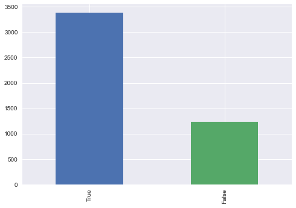

```python
lotto['gottop3'].value_counts().plot(kind='bar');
```

# Export data

```python
lotto.to_csv('./data/exports/lotto_edited.csv')
```

```python
zipdata.to_csv('./data/exports/zipdata.csv')
```

## CTIP

The Census Tract Integration Preference (CTIP) operates as a preference/tie-breaking factor in the choice student assignment system. – Designed to meet the school board’s goals to reverse the trend of racial isolation and the concentration of underserved students in the same school, and provide equitable access to the range of opportunities offered to students – Based on average test scores – Children living in areas of the city with the lowest average test scores get the CTIP1 tiebreaker

## How many CTIP applicants are there?

> **705**

```python
zipdata['Does Student Live In CTIP1 Zone? (y/n)'].value_counts()
```

```
0    3906
1     705
Name: Does Student Live In CTIP1 Zone? (y/n), dtype: int64
```

## Did any of the CTIP applicants apply late?

> **no**

```python
ctip_1 = zipdata[(zipdata['Does Student Live In CTIP1 Zone? (y/n)']==1)]
print(ctip_1)
```

```
      StudentNo  Round 1 Assignment  School Enrolled In As Of 11/03/2017  \
4             5                 420                                  420
8             9                 420                                  420
11           12                 676                                  676
35           36                 485                                  485
36           37                 760                                  760
49           50                 723                                  723
55           56                 420                                  420
66           67                 603                                  603
69           70                 714                                  517
78           79                 786                                  786
92           93                 680                                  680
97           98                 420                                  420
98           99                 420                                  844
99          100                 859                                  859
```

[output cut: 112 more lines]

```python
ctip_late = ctip_1['Round 1 Assignment']
ctip_late.isna().sum()
```

```
0
```

## How many CTIP applicants were assigned their top choice school? compared to non CTIP applicants?

```python
zipdata['got1stchoice'] = np.where(zipdata['Round 1 Assignment'] == zipdata['School Enrolled In As Of 11/03/2017'], 0, 1)
```

```python
zipdata.head()
```

|  | StudentNo | Round 1 Assignment | School Enrolled In As Of 11/03/2017 | Does Student Live In CTIP1 Zone? (y/n) | Student's Residential Zip Code | got1stchoice |
| --- | --- | --- | --- | --- | --- | --- |
| 0 | 1 | 848 | 848 | 0 | 94118 | 0 |
| 1 | 2 | 729 | 729 | 0 | 94112 | 0 |
| 2 | 3 | 722 | 722 | 0 | 94131 | 0 |
| 3 | 4 | 782 | 782 | 0 | 94127 | 0 |
| 4 | 5 | 420 | 420 | 1 | 94110 | 0 |

```python
zipdata.groupby(['Does Student Live In CTIP1 Zone? (y/n)', 'got1stchoice']).size()
```

```
Does Student Live In CTIP1 Zone? (y/n)  got1stchoice
0                                       0               2667
                                        1               1239
1                                       0                617
                                        1                 88
dtype: int64
```

## Where did CTIP applicants end up?

```python
codes = pd.read_csv('./data/codes/master_schools_list_complete.csv')
df_codes = codes.copy()
```

```python
codes.head()
```

|  | Unnamed: 0 | school_name_x | district_code | cds_code | school_name_y | campus_address | zipcode |
| --- | --- | --- | --- | --- | --- | --- | --- |
| 0 | 0 | Alamo ES | 413 | 6040695 | Alamo Elementary School | 250 23RD AVE | 94121 |
| 1 | 84 | Alice Fong Yu ES | 801 | 6113245 | Yu, Alice Fong Yu Alternative School | 1541 12TH AVE | 94122 |
| 2 | 1 | Alvarado ES | 420 | 6040703 | Alvarado Elementary School | 625 DOUGLASS ST | 94114 |
| 3 | 2 | Argonne ES | 435 | 6040737 | Argonne Elementary School | 680 18TH AVE | 94121 |
| 4 | 3 | Bryant ES | 456 | 6040778 | Bryant Early Education / Bryant Elementary | 2641 25TH ST | 94110 |

```python
codes.rename(columns={'zipcode' : 'campus_zipcode'}, inplace=True)
```

```python
codes.columns
```

```
Index(['Unnamed: 0', 'school_name_x', 'district_code', 'cds_code',
       'school_name_y', 'campus_address', 'campus_zipcode'],
      dtype='object')
```

```python
codes = codes.infer_objects()
```

```python
codes.columns
```

```
Index(['Unnamed: 0', 'school_name_x', 'district_code', 'cds_code',
       'school_name_y', 'campus_address', 'campus_zipcode'],
      dtype='object')
```

```python
codes.info()
```

```
<class 'pandas.core.frame.DataFrame'>
RangeIndex: 85 entries, 0 to 84
Data columns (total 7 columns):
Unnamed: 0        85 non-null int64
school_name_x     85 non-null object
district_code     85 non-null int64
cds_code          85 non-null int64
school_name_y     84 non-null object
campus_address    84 non-null object
campus_zipcode    85 non-null int64
dtypes: int64(4), object(3)
memory usage: 4.7+ KB
```

```python
codes.head()
```

|  | Unnamed: 0 | school_name_x | district_code | cds_code | school_name_y | campus_address | campus_zipcode |
| --- | --- | --- | --- | --- | --- | --- | --- |
| 0 | 0 | Alamo ES | 413 | 6040695 | Alamo Elementary School | 250 23RD AVE | 94121 |
| 1 | 84 | Alice Fong Yu ES | 801 | 6113245 | Yu, Alice Fong Yu Alternative School | 1541 12TH AVE | 94122 |
| 2 | 1 | Alvarado ES | 420 | 6040703 | Alvarado Elementary School | 625 DOUGLASS ST | 94114 |
| 3 | 2 | Argonne ES | 435 | 6040737 | Argonne Elementary School | 680 18TH AVE | 94121 |
| 4 | 3 | Bryant ES | 456 | 6040778 | Bryant Early Education / Bryant Elementary | 2641 25TH ST | 94110 |

```python
ctip_1.head()
```

|  | StudentNo | Round 1 Assignment | School Enrolled In As Of 11/03/2017 | Does Student Live In CTIP1 Zone? (y/n) | Student's Residential Zip Code |
| --- | --- | --- | --- | --- | --- |
| 4 | 5 | 420 | 420 | 1 | 94110 |
| 8 | 9 | 420 | 420 | 1 | 94107 |
| 11 | 12 | 676 | 676 | 1 | 94107 |
| 35 | 36 | 485 | 485 | 1 | 94124 |
| 36 | 37 | 760 | 760 | 1 | 94124 |

```python
ctip_enrolled = ctip_1.drop(['Round 1 Assignment'], axis=1)
```

```python
ctip_enrolled.head()
```

|  | StudentNo | School Enrolled In As Of 11/03/2017 | Does Student Live In CTIP1 Zone? (y/n) | Student's Residential Zip Code |
| --- | --- | --- | --- | --- |
| 4 | 5 | 420 | 1 | 94110 |
| 8 | 9 | 420 | 1 | 94107 |
| 11 | 12 | 676 | 1 | 94107 |
| 35 | 36 | 485 | 1 | 94124 |
| 36 | 37 | 760 | 1 | 94124 |

```python
ctip_enrolled.rename(columns={'School Enrolled In As Of 11/03/2017' : 'district_code'}, inplace=True)
```

```python
ctip_enrolled_w_school_zip = pd.merge(ctip_enrolled, codes, on='district_code', how='outer')
```

```python
ctip_enrolled_w_school_zip.info()
```

```
<class 'pandas.core.frame.DataFrame'>
Int64Index: 754 entries, 0 to 753
Data columns (total 10 columns):
StudentNo                                 739 non-null float64
district_code                             727 non-null float64
Does Student Live In CTIP1 Zone? (y/n)    739 non-null float64
Student's Residential Zip Code            739 non-null float64
Unnamed: 0                                694 non-null float64
school_name_x                             694 non-null object
cds_code                                  694 non-null float64
school_name_y                             690 non-null object
campus_address                            690 non-null object
campus_zipcode                            694 non-null float64
dtypes: float64(7), object(3)
memory usage: 64.8+ KB
```

```python
ctip_enrolled_w_school_zip['campus_zipcode'] = ctip_enrolled_w_school_zip['campus_zipcode'].fillna(0).astype(int)
ctip_enrolled_w_school_zip['campus_zipcode'] = ctip_enrolled_w_school_zip['campus_zipcode'].astype(np.int64)
ctip_enrolled_w_school_zip['Student\'s Residential Zip Code'] = ctip_enrolled_w_school_zip['Student\'s Residential Zip Code'].fillna(0).astype(int)
ctip_enrolled_w_school_zip['Student\'s Residential Zip Code'] = ctip_enrolled_w_school_zip['Student\'s Residential Zip Code'].astype(np.int64)
ctip_enrolled_w_school_zip['cds_code'] = ctip_enrolled_w_school_zip['cds_code'].fillna(0).astype(int)
ctip_enrolled_w_school_zip['cds_code'] = ctip_enrolled_w_school_zip['cds_code'].astype(np.int64)
```

```python
ctip_enrolled_w_school_zip.info()
```

```
<class 'pandas.core.frame.DataFrame'>
Int64Index: 754 entries, 0 to 753
Data columns (total 10 columns):
StudentNo                                 739 non-null float64
district_code                             727 non-null float64
Does Student Live In CTIP1 Zone? (y/n)    739 non-null float64
Student's Residential Zip Code            754 non-null int64
Unnamed: 0                                694 non-null float64
school_name_x                             694 non-null object
cds_code                                  754 non-null int64
school_name_y                             690 non-null object
campus_address                            690 non-null object
campus_zipcode                            754 non-null int64
dtypes: float64(4), int64(3), object(3)
memory usage: 64.8+ KB
```

```python
ctip_enrolled_w_school_zip.head()
```

|  | StudentNo | district_code | Does Student Live In CTIP1 Zone? (y/n) | Student's Residential Zip Code | Unnamed: 0 | school_name_x | cds_code | school_name_y | campus_address | campus_zipcode |
| --- | --- | --- | --- | --- | --- | --- | --- | --- | --- | --- |
| 0 | 5 | 420 | 1 | 94110 | 1 | Alvarado ES | 6040703 | Alvarado Elementary School | 625 DOUGLASS ST | 94114 |
| 1 | 9 | 420 | 1 | 94107 | 1 | Alvarado ES | 6040703 | Alvarado Elementary School | 625 DOUGLASS ST | 94114 |
| 2 | 56 | 420 | 1 | 94110 | 1 | Alvarado ES | 6040703 | Alvarado Elementary School | 625 DOUGLASS ST | 94114 |
| 3 | 98 | 420 | 1 | 94110 | 1 | Alvarado ES | 6040703 | Alvarado Elementary School | 625 DOUGLASS ST | 94114 |
| 4 | 169 | 420 | 1 | 94107 | 1 | Alvarado ES | 6040703 | Alvarado Elementary School | 625 DOUGLASS ST | 94114 |

```python
ctip_enrolled_w_school_zip['enrolled_in_home_zipcode'] = np.where(ctip_enrolled_w_school_zip['Student\'s Residential Zip Code'] == ctip_enrolled_w_school_zip['campus_zipcode'], 0, 1)
```

```python
ctip_enrolled_w_school_zip.head()
```

|  | StudentNo | district_code | Does Student Live In CTIP1 Zone? (y/n) | Student's Residential Zip Code | Unnamed: 0 | school_name_x | cds_code | school_name_y | campus_address | campus_zipcode | enrolled_in_home_zipcode |
| --- | --- | --- | --- | --- | --- | --- | --- | --- | --- | --- | --- |
| 0 | 5 | 420 | 1 | 94110 | 1 | Alvarado ES | 6040703 | Alvarado Elementary School | 625 DOUGLASS ST | 94114 | 1 |
| 1 | 9 | 420 | 1 | 94107 | 1 | Alvarado ES | 6040703 | Alvarado Elementary School | 625 DOUGLASS ST | 94114 | 1 |
| 2 | 56 | 420 | 1 | 94110 | 1 | Alvarado ES | 6040703 | Alvarado Elementary School | 625 DOUGLASS ST | 94114 | 1 |
| 3 | 98 | 420 | 1 | 94110 | 1 | Alvarado ES | 6040703 | Alvarado Elementary School | 625 DOUGLASS ST | 94114 | 1 |
| 4 | 169 | 420 | 1 | 94107 | 1 | Alvarado ES | 6040703 | Alvarado Elementary School | 625 DOUGLASS ST | 94114 | 1 |

```python
ctip_enrolled_w_school_zip.enrolled_in_home_zipcode.value_counts()
```

```
1    559
0    195
Name: enrolled_in_home_zipcode, dtype: int64
```

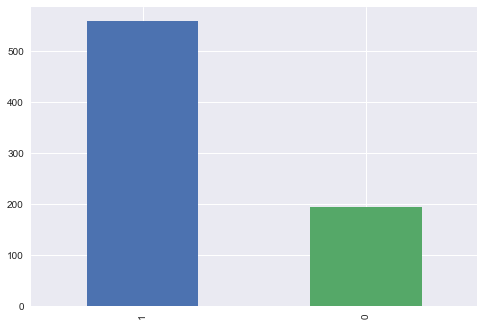

```python
ctip_enrolled_w_school_zip['enrolled_in_home_zipcode'].value_counts().plot(kind='bar');
```

```python
import pdfkit
pdfkit.from_file('online-job-postings.html', 'online-job-postings.pdf')
```